# Impact of dysfunctional ubiquitination in response to cancer immunotherapy

Somatic mutations analysis - Ubiquitin custom Gene Sets

Eric Bautista Farrerons (s212514)

First created on March 2024. Updated on 18 April 2024

# 1 Load data

```r
### Load required libraries
library(readxl)
library(tidyverse)
library(purrr)
library(dplyr)
library(knitr)
library(DT)
library(httr)
library(jsonlite)
library(stringr)
library(GSEABase)
library(HGNChelper)
library(mygene)
library(GO.db)
library(AnnotationDbi)

### Load functions
source(file = "../02_functions.R")

### Define paths
current_dir <- getwd()
data_path <- file.path(current_dir,
                       "../../data/_raw")
results_pc_path <- file.path(current_dir,
                              "../../results/patient_characteristics/output")
results_fip_path <- file.path(current_dir,
                              "../../results/somatic_mutation_analysis/functional_impact_prediction/output")
results_ubgenesets_path <- file.path(current_dir,
                                 "../../results/somatic_mutation_analysis/ubiquitin_custom_GS/output")

# Create the folder if it does not exist
if(!file.exists(results_ubgenesets_path)) {
  dir.create(results_ubgenesets_path, recursive = TRUE)
}

figures_ubgenesets_path <- file.path(current_dir,
                                 "../../results/somatic_mutation_analysis/ubiquitin_custom_GS/figures")

# Create the folder if it does not exist
if(!file.exists(figures_ubgenesets_path)) {
  dir.create(figures_ubgenesets_path, recursive = TRUE)
}

maf_df_path <- file.path(results_fip_path, "all_mutations.csv") # All mutations df
nonsyn_df_path <- file.path(results_fip_path, "nonsyn_mutations.csv") # Nonsyn mutations df
lof_df_path <- file.path(results_fip_path, "lof_mutations_reduced.csv") # LoF mutations df

# Sup1 data
sup1_response_path <- file.path(results_pc_path,
                           "sup1_response.csv")
### Read data & wrangle

# Read 3 lists of mutations

# All
maf_df_annotated <- read.csv(maf_df_path, header = TRUE)[ , -1]
list_of_all_mutations <- split(maf_df_annotated, maf_df_annotated$sample_id
                               )
# Nonsyn
nonsyn_df_annotated <- read.csv(nonsyn_df_path, header = TRUE)[ , -1]
list_of_nonsyn_mutations <- split(nonsyn_df_annotated, nonsyn_df_annotated$sample_id)

# LoF
lof_df_annotated <- read.csv(lof_df_path, header = TRUE)[ , -1]
list_of_lof_mutations <- split(lof_df_annotated, lof_df_annotated$sample_id)

# Get the list of patient IDs
sample_id_list <- unique(maf_df_annotated$sample_id)

## Read sup1_response.csv
sup1_response_df <- read.csv(sup1_response_path)[ , -1] # Drop first column

# df to merge response info later
response_df <- sup1_response_df %>%
  dplyr::rename(sample_id = Sample.ID,
                patient_response = Patient.Response) %>%
  dplyr::select(sample_id, patient_response)

# Create a list of Responders and Non-responders
sample_id_lists <- split(sup1_response_df$Sample.ID,
                         sup1_response_df$Patient.Response) # Split the "Sample.ID" values into lists based on "Patient.Response"

r_sample_ids <- sample_id_lists$R
nr_sample_ids <- sample_id_lists$NR
```

# 2 Correcting Hugo Symbols in input data

```r
# Load the GMT file
gene_sets_collection <- getGmt(file.path(data_path, "ubgenes.gmt"))

# Initialize an empty data frame for gene IDs
corrected_hsymbols <- data.frame()

# Extract gene sets and their descriptions
for (gene_set_id in names(gene_sets_collection)) {
  gene_set <- gene_sets_collection[[gene_set_id]]
  gene_ids <- geneIds(gene_set)

  # Replace "/" with "-" in gene IDs
  gene_ids <- gsub("/", "-", gene_ids)

  # Reverse date-like hugo symbols
  gene_ids <- correct_date_like_symbols(gene_ids)

  # Create a temporary data frame for this gene set
  temp_df <- checkGeneSymbols(gene_ids)

  # Combine with the main data frame
  corrected_hsymbols <- rbind(corrected_hsymbols, temp_df)
}

# Split the gene_id where "///" is found and keep only the second part (if exists)
corrected_hsymbols$Suggested.Symbol <- sapply(str_split(corrected_hsymbols$Suggested.Symbol, " /// "), function(x) {
  if (length(x) > 1) {
    # If there's more than one part, keep the second one
    return(trimws(x[2]))
  } else {
    # If there's only one part, keep it as is
    return(trimws(x[1]))
  }
})

corrected_hsymbols <- corrected_hsymbols %>%
  dplyr::rename(c(hugo_symbol = x,
                  corrected_hugo_symbol = Suggested.Symbol)) %>%
  dplyr::select(hugo_symbol, corrected_hugo_symbol)
```

# 3 Filtering lists to only include Ubiquitin-related genes

```r
# Map HUGO symbols to Ensembl Gene IDs
corrected_hsymbols$ensembl_id <- SYMBOLtoENSEMBL(corrected_hsymbols$corrected_hugo_symbol)

# Check missing Ensembl IDs
missing_ensembl <- corrected_hsymbols %>%
  dplyr::filter(!str_detect(ensembl_id, "^ENSG"))

# Find them manually and update df (for now only Ensembl Gene IDs)
missing_ensembl <- missing_ensembl %>%
  dplyr::mutate(
    # corrected_hugo_symbol = case_when(
  #   hugo_symbol == "UBE2L5" ~ "UBE2L5P",
  #   hugo_symbol == "BABAM2" ~ "BRE",
  #   hugo_symbol == "COP1" ~ "RFWD2",
  #   hugo_symbol == "DCAF1" ~ "VPRBP",
  #   hugo_symbol == "DMAC2" ~ "ATP5SL",
  #   hugo_symbol == "ELOB" ~ "TCEB2",
  #   hugo_symbol == "FBH1" ~ "FBXO18",
  #   hugo_symbol == "FBXL21P" ~ "FBXL21",
  #   hugo_symbol == "MARCHF6" ~ "MARCH6",
  #   hugo_symbol == "1-Mar" ~ "MARCH1",
  #   hugo_symbol == "10-Mar" ~ "MARCH10",
  #   hugo_symbol == "11-Mar" ~ "MARCH11",
  #   hugo_symbol == "2-Mar" ~ "MARCH2",
  #   hugo_symbol == "3-Mar" ~ "MARCH3",
  #   hugo_symbol == "4-Mar" ~ "MARCH4",
  #   hugo_symbol == "5-Mar" ~ "MARCH5",
  #   hugo_symbol == "6-Mar" ~ "MARCH6",
  #   hugo_symbol == "7-Mar" ~ "MARCH7",
  #   hugo_symbol == "8-Mar" ~ "MARCH8",
  #   hugo_symbol == "9-Mar" ~ "MARCH9",
  #   hugo_symbol == "PARK2" ~ "PARK2",
  #   hugo_symbol == "RFWD2" ~ "RFWD2",
  #   hugo_symbol == "RNF212B" ~ "C14orf164",
  #   hugo_symbol == "RNF219" ~ "RNF219",
  #   hugo_symbol == "RNF225" ~ "RNF225",
  #   hugo_symbol == "TRIM75P" ~ "TRIM75P",
  #   hugo_symbol == "ZNF645" ~ "ZNF645",
  #   hugo_symbol == "USP17L1" ~ "USP17L1P",
  #   hugo_symbol == "OTULIN" ~ "FAM105B",
  #   TRUE ~ corrected_hugo_symbol
  # ),
  ensembl_id = case_when(
    hugo_symbol == "UBE2L5" ~ "ENSG00000236444",
    hugo_symbol == "BABAM2" ~ "ENSG00000158019",
    hugo_symbol == "COP1" ~ "ENSG00000143207",
    hugo_symbol == "DCAF1" ~ "ENSG00000145041",
    hugo_symbol == "DMAC2" ~ "ENSG00000105341",
    hugo_symbol == "ELOB" ~ "ENSG00000103363",
    hugo_symbol == "FBH1" ~ "ENSG00000134452",
    hugo_symbol == "FBXL21P" ~ "ENSG00000164616",
    hugo_symbol == "MARCHF6" ~ "ENSG00000145495",
    hugo_symbol == "1-Mar" ~ "ENSG00000145416",
    hugo_symbol == "10-Mar" ~ "ENSG00000173838",
    hugo_symbol == "11-Mar" ~ "ENSG00000183654",
    hugo_symbol == "2-Mar" ~ "ENSG00000099785",
    hugo_symbol == "3-Mar" ~ "ENSG00000173926",
    hugo_symbol == "4-Mar" ~ "ENSG00000144583",
    hugo_symbol == "5-Mar" ~ "ENSG00000198060",
    hugo_symbol == "6-Mar" ~ "ENSG00000145495",
    hugo_symbol == "7-Mar" ~ "ENSG00000136536",
    hugo_symbol == "8-Mar" ~ "ENSG00000165406",
    hugo_symbol == "9-Mar" ~ "ENSG00000139266",
    hugo_symbol == "PARK2" ~ "ENSG00000185345",
    hugo_symbol == "RFWD2" ~ "ENSG00000143207",
    hugo_symbol == "RNF212B" ~ "ENSG00000215277",
    hugo_symbol == "RNF219" ~ "ENSG00000152193",
    hugo_symbol == "RNF225" ~ "ENSG00000269855",
    hugo_symbol == "TRIM75P" ~ "ENSG00000250374",
    hugo_symbol == "ZNF645" ~ "ENSG00000175809",
    hugo_symbol == "USP17L1" ~ "ENSG00000230549",
    hugo_symbol == "OTULIN" ~ "ENSG00000154124",
    TRUE ~ ensembl_id
  ))

# Merge the dataframes
corrected_hsymbols_updated <- corrected_hsymbols %>%
  left_join(dplyr::select(missing_ensembl,
                          hugo_symbol,
                          # new_corrected_hugo_symbol = corrected_hugo_symbol,
                          new_ensembl_id = ensembl_id),
            by = "hugo_symbol")

# Update the values based on the join
corrected_hsymbols_updated <- corrected_hsymbols_updated %>%
  dplyr::mutate(
    # corrected_hugo_symbol = ifelse(!is.na(new_corrected_hugo_symbol), new_corrected_hugo_symbol, corrected_hugo_symbol),
    ensembl_id = ifelse(!is.na(new_ensembl_id), new_ensembl_id, ensembl_id)
    ) %>%
  dplyr::select(
    # -new_corrected_hugo_symbol,
    -new_ensembl_id)

# Extract the ensembl_id column to do the filtering
ubiquitin_df <- corrected_hsymbols_updated %>%
  dplyr::select(ensembl_id)

# Get ubiquitin unique ensembl ids
ub_ensembl_ids <- unique(corrected_hsymbols_updated$ensembl_id)

# Filter for ubiquitin genes in all the mutation lists
list_of_all_ub_mutations <- ubiquitin_filter(list_of_all_mutations, ubiquitin_df)
list_of_nonsyn_ub_mutations <- ubiquitin_filter(list_of_nonsyn_mutations, ubiquitin_df)
list_of_lof_ub_mutations <- ubiquitin_filter(list_of_lof_mutations, ubiquitin_df)

# Bind rows to re-generate the dataframes
all_df_ubiquitin <- bind_rows(list_of_all_ub_mutations)
nonsyn_df_ubiquitin <- bind_rows(list_of_nonsyn_ub_mutations)
lof_df_ubiquitin <- bind_rows(list_of_lof_ub_mutations)

# Get all unique sample_id values
unique_sample_ids <- unique(list_of_lof_ub_mutations$sample_id)
```

# 4 Summary of mutations per patient

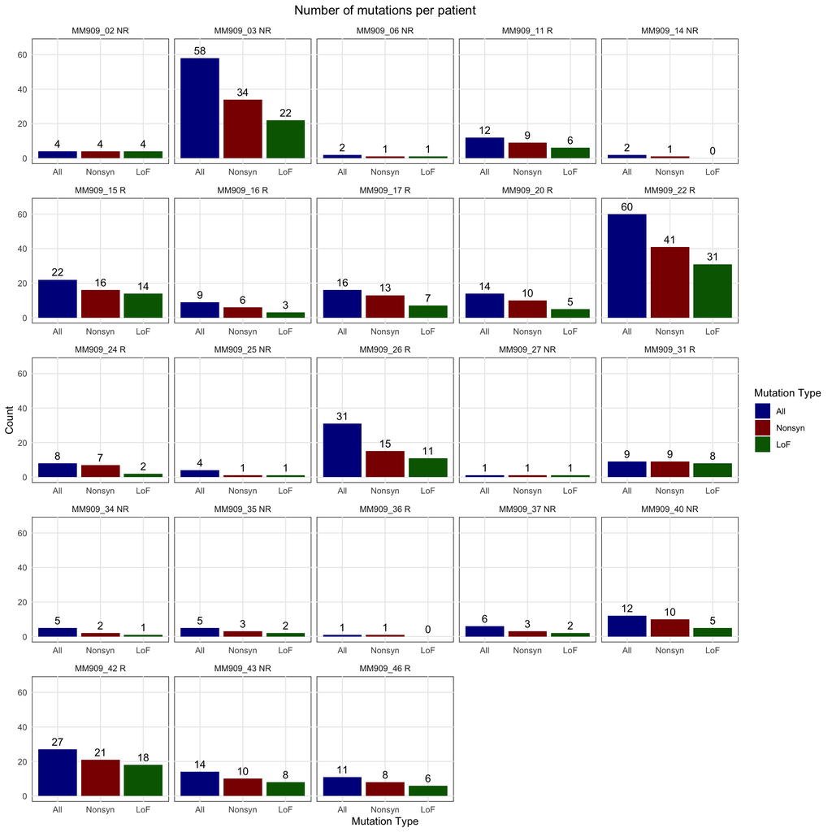

```r
# Define output path
mm909_sum_plot_path <- file.path(figures_ubgenesets_path,
                              "mm909_sum_plot.png")

# Summary plot
mm909_sum_plot <- sum_plot(response_df, all_df_ubiquitin, nonsyn_df_ubiquitin, lof_df_ubiquitin, mm909_sum_plot_path)

# Display
print(mm909_sum_plot)
```

Sample MM909_47 does not have any Ubiquitin-related gene, and MM909_14, MM909_36 don’t have any LoF on ubiquitin genes.

# 5 Build a DB of GO terms for ubiquitin-related Bio Processes (based on gene list)

#### 5.0.0.1 Get all GO.db terms.

#### 5.0.0.2 Query GO database using mygene to find GO terms for Ub genes (gmt file).

#### 5.0.0.3 Use grch37 and PFAM to recover lost genes. The rest annotate manually: Ensembl & UniProt mainly.

#### 5.0.0.4 Define categories. Define which parent terms I want to use and get offspring.

#### 5.0.0.5 Build the DB with Category > Parent > Children.

#### 5.0.0.6 Iterate through the ubiquitin terms from GO.db and annotate the parent terms. Make a data.frame.

#### 5.0.0.7 Check the ones that have +1 GO parent term and reduce to 1.

#### 5.0.0.8 Get more parent terms for lost genes and repeat 2 previous steps.

#### 5.0.0.9 Get Ensembl IDs related to those GO terms.

#### 5.0.0.10 Perform FORA and make plots.

```r
#1 Get all GO terms related to ubiquitin and filter for BP
ubiquitin_terms <- searchGOTerms("ubiquitin")
ub_godb_bp_df <- ubiquitin_terms %>%
  # dplyr::filter(go_category == "BP") %>%
  dplyr::select(go_id, go_term, go_category) %>%
  dplyr::distinct()

#1 Get all GO terms to merge later. Do not filter for BP
all_go_terms <- as.list(GOTERM)

#2 Query GO database using mygene to find GO terms of Ub genes

# Query the database to find GO terms associated to each gene
go_ubgenes_result <- queryMany(ub_ensembl_ids,
                 scopes='ensembl.gene',
                 fields=c('ensembl.gene', 'name', 'summary', 'go', 'pfam'),
                 species='human',
                 return.as='DataFrame')
```

```
## Finished
## Pass returnall=TRUE to return lists of duplicate or missing query terms.
```

```r
# Filter result for BP
go_ubgenes_bp_res <- go_ubgenes_result$go.BP # Filter for BP only
names(go_ubgenes_bp_res) <- ub_ensembl_ids # Set names

# Convert to data.frame each element of the list
go_ubgenes_bp_list <- lapply(go_ubgenes_bp_res,
                             function(df)
                               if (is.null(df)) data.frame(id = character(),
                                                           gocategory = character(),
                                                           term = character())
                               else df %>%
                                as.data.frame())
# Wrangle the data.frame
go_ubgenes_bp_list <- lapply(go_ubgenes_bp_list,
                             function(x)
                               x %>%
                                dplyr::rename(go_id = id,
                                              go_term = term,
                                              go_category = gocategory) %>%
                                dplyr::select(go_category,
                                              go_id,
                                              go_term))
# Convert list of df to single data.frame
raw_ub_glist_go_bp_df <- bind_rows(go_ubgenes_bp_list, .id = "ensembl_id") %>%
  dplyr::distinct()

# Here I lose 28 genes because GO annotation failed. Collect them for exploration.
empty_dfs <- sapply(go_ubgenes_bp_list, function(x) dim(x)[1] == 0)
lost_genes <- ub_ensembl_ids[empty_dfs]

#3 Recover lost genes
# Recover some using BiomaRt with grch37
# Connect to the GO BioMart database
ensembl = biomaRt::useMart(biomart="ENSEMBL_MART_ENSEMBL",
                  host="https://grch37.ensembl.org",
                  path="/biomart/martservice",
                  dataset="hsapiens_gene_ensembl")

# Retrieve GO & Ensembl gene ids
ensembl2go_biomart_res <- biomaRt::getBM(attributes = c("namespace_1003",
                                                        "name_1006",
                                                        "go_id",
                                                        "ensembl_gene_id"),
                   filters = "ensembl_gene_id",
                   values = lost_genes,
                   mart = ensembl)

# Filter for biological_process
ensembl2go_bp_res <- ensembl2go_biomart_res %>%
  dplyr::rename(go_category = namespace_1003,
                go_term = name_1006,
                ensembl_id = ensembl_gene_id) %>%
  dplyr::filter(go_category == "biological_process") %>%
  dplyr::mutate(go_category = ifelse(go_category == "biological_process", "BP", go_category)) %>%
  dplyr::distinct() %>%
  dplyr::select(ensembl_id, go_category, go_id, go_term) # Re-arrange

# Append to raw_ub_glist_go_bp_df
raw_ub_glist_go_bp_df <- bind_rows(raw_ub_glist_go_bp_df, ensembl2go_bp_res)

# Here I lose 19 genes because GO annotation failed. Recovered 9 using grch37. Collect them for exploration.
lost_genes2 <- setdiff(ub_ensembl_ids, raw_ub_glist_go_bp_df$ensembl_id)

# Annotate using PFAM where possible
# Get PFAM for lost_genes2
# Filter result for pfam
pfam_ubgenes <- go_ubgenes_result$pfam
names(pfam_ubgenes) <- ub_ensembl_ids # Set names

# Find pfam for lost_genes2
pfam_lost_genes <- pfam_ubgenes[names(pfam_ubgenes) %in% lost_genes2]

# Remove the ones that have NULL and collect for manual annotation.
# Identify NULL elements
null_elements <- sapply(pfam_lost_genes, is.null)

# Remove NULL elements from pfam_lost_genes
pfam_lost_genes <- pfam_lost_genes[!null_elements]

# Convert to df
pfam_ubgenes_df <- pfam_ubgenes %>%
  tibble::enframe(name = "ensembl_id", value = "pfam") %>%
  tidyr::unnest(pfam) %>%
  dplyr::distinct()

pfam_lost_genes_df <- pfam_lost_genes %>%
  tibble::enframe(name = "ensembl_id", value = "pfam") %>%
  tidyr::unnest(pfam) %>%
  dplyr::distinct()

# Check if another annotated gene has the same PFAM domain and annotate it
# Perform an inner join on the pfam column
shared_pfam_df <- pfam_lost_genes_df %>%
  dplyr::inner_join(pfam_ubgenes_df, by = "pfam", suffix = c("_lost", "_ub")) %>%
  # Filter out rows where ensembl_id matches between the two dataframes
  dplyr::filter(ensembl_id_lost != ensembl_id_ub)

# Query PFAM domains to get GO terms
query_pfam <- unique(pfam_lost_genes_df$pfam)
pfam_ubgenes_result <- queryMany(query_pfam,
                 scopes='pfam',
                 fields=c('ensembl.gene', 'name', 'go', 'pfam'),
                 species='human',
                 return.as='DataFrame')
```

```
## Finished
## Pass returnall=TRUE to return lists of duplicate or missing query terms.
```

```r
# Filter result for BP
pfam_ubgenes_bp_res <- pfam_ubgenes_result$go.BP # Filter for BP only
query_names <- pfam_ubgenes_result$query
query_ensembl <- pfam_ubgenes_result$ensembl

# Set names
names(pfam_ubgenes_bp_res) <- query_names
names(query_ensembl) <- query_names

# Convert to data.frame each element of the list
pfam_ubgenes_bp_list <- lapply(pfam_ubgenes_bp_res,
                             function(df)
                               if (is.null(df)) data.frame(id = character(),
                                                           gocategory = character(),
                                                           term = character())
                               else df %>%
                                as.data.frame())
# Wrangle the data.frame
pfam_ubgenes_bp_list <- lapply(pfam_ubgenes_bp_list,
                             function(x)
                               x %>%
                                dplyr::rename(go_id = id,
                                              go_term = term,
                                              go_category = gocategory) %>%
                                dplyr::select(go_category,
                                              go_id,
                                              go_term))

pfam_ubgenes_bp_list_with_ensembl <- lapply(names(pfam_ubgenes_bp_list), function(name) {
  # Extract the corresponding dataframe
  df <- pfam_ubgenes_bp_list[[name]]

  # Extract the corresponding ensembl_id, ensure it's not a list but a single value or a vector of the same value
  ensembl_id <- rep(query_ensembl[name], ifelse(is.null(df), 1, nrow(df)))

  # Handle the case where the dataframe is NULL or empty
  if(is.null(df) || nrow(df) == 0) {
    # Create a dataframe with a single row indicating NA entries except for the ensembl_id
    df <- data.frame(go_id = NA, go_category = NA, go_term = NA, stringsAsFactors = FALSE)
    n <- length(ensembl_id) # Ensure there's at least one row for the ensembl_id
    df <- df[rep(1, n), ]
  }

  # Assign the ensembl_id(s)
  df$ensembl_id <- ensembl_id

  df
})

# Set names again
names(pfam_ubgenes_bp_list_with_ensembl) <- query_names

# Ensure every dataframe in the list has columns of the correct type, handling empty dataframes explicitly
pfam_ubgenes_bp_list_standardized <- purrr::map(pfam_ubgenes_bp_list_with_ensembl, function(df) {
  if(nrow(df) == 0) { # Check if the dataframe is empty
    # Explicitly define the dataframe with the correct types for each column
    df <- data.frame(go_id = character(),
                     go_category = character(),
                     go_term = character(),
                     ensembl_id = character(),
                     stringsAsFactors = FALSE)
  } else {
    # For non-empty dataframes, ensure all columns are of type character
    df$go_id <- as.character(df$go_id)
    df$go_category <- as.character(df$go_category)
    df$go_term <- as.character(df$go_term)
    df$ensembl_id <- as.character(unlist(df$ensembl_id))
  }
  df
})

# Now combine the standardized list of dataframes into a single dataframe
pfam2go_res_df <- bind_rows(pfam_ubgenes_bp_list_standardized, .id = "pfam") %>%
  dplyr::distinct() %>%
  dplyr::rename(ensembl_id_ub = ensembl_id)

# Map pfam2go_res_df to shared_pfam_df by ensembl_id_ub
found_pfam_df <- pfam2go_res_df %>%
  dplyr::inner_join(shared_pfam_df, by = c("ensembl_id_ub", "pfam")) %>%
  # Filter out rows where ensembl_id matches between the two dataframes
  dplyr::filter(ensembl_id_lost != ensembl_id_ub)

# Arrange df to merge with raw_ub_glist_go_bp_df
merge_pfam2go <- found_pfam_df %>%
  dplyr::select(ensembl_id_lost, go_category, go_id, go_term) %>%
  dplyr::rename(ensembl_id = ensembl_id_lost)

# Merge with previous df
raw_ub_glist_go_bp_df <- bind_rows(raw_ub_glist_go_bp_df, merge_pfam2go) %>%
  dplyr::distinct()

# Collect not annotated genes for manual annotation.
lost_genes3 <- setdiff(ub_ensembl_ids, raw_ub_glist_go_bp_df$ensembl_id)

# Here, I still have 14 genes for which I don't have GO term. Recovered 5 with PFAM.

# Manually annotate the remaining 14 genes.
manual_annot_df <- data.frame(
  ensembl_id = lost_genes3,
  go_category = rep("", length(lost_genes3)),
  go_id = rep("", length(lost_genes3)),
  go_term = rep("", length(lost_genes3)),
  stringsAsFactors = FALSE
)
manual_annot_df <- manual_annot_df %>%
  dplyr::mutate(
    go_id = case_when(
      ensembl_id == "ENSG00000131982" ~ "GO:0016567",
      ensembl_id == "ENSG00000267741" ~ "GO:0000209",
      ensembl_id == "ENSG00000198354" ~ "GO:0080008",
      ensembl_id == "ENSG00000226372" ~ "GO:0080008",
      ensembl_id == "ENSG00000189186" ~ "GO:0080008",
      ensembl_id == "ENSG00000164616" ~ "GO:0016567",
      ensembl_id == "ENSG00000187954" ~ "GO:0008270",
      ensembl_id == "ENSG00000238222" ~ "GO:0016567",
      ensembl_id == "ENSG00000010318" ~ "GO:0046872",
      ensembl_id == "ENSG00000167257" ~ "GO:0004842",
      ensembl_id == "ENSG00000189051" ~ "GO:0046872",
      ensembl_id == "ENSG00000233198" ~ "GO:0046872",
      ensembl_id == "ENSG00000034063" ~ "GO:0006511",
      ensembl_id == "ENSG00000251694" ~ "GO:0004843",
      TRUE ~ go_id  # Keeps existing value if no condition is matched
    ),
    go_term = case_when(
      ensembl_id == "ENSG00000131982" ~ "protein ubiquitination",
      ensembl_id == "ENSG00000267741" ~ "protein polyubiquitination",
      ensembl_id == "ENSG00000198354" ~ "Cul4-RING E3 ubiquitin ligase complex",
      ensembl_id == "ENSG00000226372" ~ "Cul4-RING E3 ubiquitin ligase complex",
      ensembl_id == "ENSG00000189186" ~ "Cul4-RING E3 ubiquitin ligase complex",
      ensembl_id == "ENSG00000164616" ~ "protein ubiquitination",
      ensembl_id == "ENSG00000187954" ~ "zinc ion binding",
      ensembl_id == "ENSG00000238222" ~ "protein ubiquitination",
      ensembl_id == "ENSG00000010318" ~ "metal ion binding",
      ensembl_id == "ENSG00000167257" ~ "ubiquitin-protein transferase activity",
      ensembl_id == "ENSG00000189051" ~ "metal ion binding",
      ensembl_id == "ENSG00000233198" ~ "metal ion binding",
      ensembl_id == "ENSG00000034063" ~ "ubiquitin-dependent protein catabolic process",
      ensembl_id == "ENSG00000251694" ~ "cysteine-type deubiquitinase activity",
      TRUE ~ go_term
    ),
    go_category = case_when(
      ensembl_id == "ENSG00000131982" ~ "BP",
      ensembl_id == "ENSG00000267741" ~ "BP",
      ensembl_id == "ENSG00000198354" ~ "CC",
      ensembl_id == "ENSG00000226372" ~ "CC",
      ensembl_id == "ENSG00000189186" ~ "CC",
      ensembl_id == "ENSG00000164616" ~ "BP",
      ensembl_id == "ENSG00000187954" ~ "MF",
      ensembl_id == "ENSG00000238222" ~ "BP",
      ensembl_id == "ENSG00000010318" ~ "MF",
      ensembl_id == "ENSG00000167257" ~ "MF",
      ensembl_id == "ENSG00000189051" ~ "MF",
      ensembl_id == "ENSG00000233198" ~ "MF",
      ensembl_id == "ENSG00000034063" ~ "BP",
      ensembl_id == "ENSG00000251694" ~ "MF",
      TRUE ~ go_id  # Keeps existing value if no condition is matched
    )
  )

# Merge with previous df
raw_ub_glist_go_bp_df <- bind_rows(raw_ub_glist_go_bp_df, manual_annot_df) %>%
  dplyr::distinct()
```

```r
#4 Define categories and parents

# Categories (as character)
ub_categories <- c("ubiquitination", "deubiquitination", "ubiquitin_neutral", "ubiquitin_other")
# ub_categories <- setNames(as.list(ub_categories), ub_categories)

# Parents (as character)
ub_parent_terms <- c("GO:0016567", "GO:0016579", "GO:0006511", "GO:0010499", "GO:0010992", "GO:0070086", "GO:0120323", "GO:0031397", "GO:0031398", "GO:2000059", "GO:2000060", "GO:0046872", "GO:0004842", "GO:0051865", "GO:0000209", "GO:0006513")
# "GO:0051438" --> removed because regulation can be positive or negative
# ub_parent_terms <- setNames(as.list(ub_parent_terms), ub_parent_terms)

# Children (as list)
all_offspring_bp <- as.list(GOBPOFFSPRING) # Get the offspring terms for BP
all_offspring_mf <- as.list(GOMFOFFSPRING) # Get the offspring terms for MF
parent2child_list <- map(ub_parent_terms, function(x) {
  bp_offspring <- all_offspring_bp[[x]]
  mf_offspring <- all_offspring_mf[[x]]

  # Check if BP offspring exists and has elements
  if (!is.null(bp_offspring) && length(bp_offspring) > 0) {
    # BP has elements, return it along with the parent itself
    return(c(x, unlist(bp_offspring)))
  } else if (!is.null(bp_offspring) && length(bp_offspring) == 0) {
    # BP is empty, return the parent itself
    return(list(x))
  } else if (!is.null(mf_offspring) && length(mf_offspring) > 0) {
    # BP is NULL, but MF has elements, return MF along with the parent itself
    return(c(x, unlist(mf_offspring)))
  } else {
    # Both BP is NULL and MF is empty or NULL, return the parent itself
    return(list(x))
  }
})
names(parent2child_list) <- ub_parent_terms

# Add child terms manually to previously defined parents
parent2child_list[["GO:0016567"]] <- c(parent2child_list[["GO:0016567"]], "GO:0080008")
parent2child_list[["GO:0016579"]] <- c(parent2child_list[["GO:0016579"]], "GO:0004843")

#5 Build DB with Category > Parent > Children

ub_db <- list(
  ubiquitination = list(
    `GO:0016567` = parent2child_list[["GO:0016567"]],
    `GO:0010992` = parent2child_list[["GO:0010992"]],
    `GO:0006511` = parent2child_list[["GO:0006511"]],
    `GO:0070086` = parent2child_list[["GO:0070086"]],
    `GO:0120323` = parent2child_list[["GO:0120323"]],
    `GO:0031398` = parent2child_list[["GO:0031398"]],
    `GO:0051865` = parent2child_list[["GO:0051865"]],
    `GO:0000209` = parent2child_list[["GO:0000209"]],
    `GO:0006513` = parent2child_list[["GO:0006513"]],
    `GO:2000060` = parent2child_list[["GO:2000060"]]
  ),
  deubiquitination = list(
    `GO:0016579` = parent2child_list[["GO:0016579"]],
    `GO:0031397` = parent2child_list[["GO:0031397"]],
    `GO:2000059` = parent2child_list[["GO:2000059"]]
  ),
  ubiquitin_neutral = list(
    `GO:0004842` = parent2child_list[["GO:0004842"]] # MF
  ),
  ubiquitin_other = list(
    `GO:0010499` = parent2child_list[["GO:0010499"]],
    `GO:0046872` = parent2child_list[["GO:0046872"]] # MF
  )
)

#6 Make a data.frame with ensembl_id, go_category, category, go_parent_id, go_parent_term, go_id, go_term

# Initialize an empty list to hold the mapping
go_mapping <- list()

# Iterate through each category in ub_db
for (category in names(ub_db)) {
  # Iterate through each parent within a category
  for (parent_id in names(ub_db[[category]])) {
    # Iterate through each child within a parent
    children_ids <- ub_db[[category]][[parent_id]]
    for (child_id in children_ids) {
      # Append the category and parent information to the mapping list for each child
      if (!is.null(go_mapping[[child_id]])) {
        go_mapping[[child_id]] <- unique(c(go_mapping[[child_id]], paste(parent_id, category, sep = "|")))
      } else {
        go_mapping[[child_id]] <- paste(parent_id, category, sep = "|")
      }
    }
  }
}

# Convert the mapping list to a data.frame for easier manipulation
go_mapping_df <- stack(go_mapping)
names(go_mapping_df) <- c("info", "go_id")

# Split info into go_parent_id and category
go_mapping_df <- go_mapping_df %>%
  tidyr::separate(info, into = c("go_parent_id", "category"), sep = "\\|")

# Join the mapping information back to the original data.frame
final_df <- raw_ub_glist_go_bp_df %>%
  left_join(go_mapping_df, by = "go_id")

#7 Handle cases where a child belongs to multiple parents
final_df <- final_df %>%
  dplyr::group_by(ensembl_id, go_category, go_id, go_term) %>%
  dplyr::summarise(go_parent_id = paste(unique(go_parent_id), collapse = ", "),
            category = paste(unique(category), collapse = ", "),
            .groups = 'drop')

# Arrange columns in the desired order
final_df <- final_df %>%
  dplyr::select(ensembl_id, go_category, category, go_parent_id, go_term, go_id)

# Converting NAs and ordering columns
annot_ub_glist_df <- final_df %>%
  dplyr::mutate(across(everything(), ~na_if(.x, "NA"))) %>%
  dplyr::select(ensembl_id,
                go_category,
                category,
                go_parent_id,
                go_id,
                go_term)

# DEBUG: check category
# rows_with_multiple_categories <- annot_ub_glist_df %>%
#   dplyr::filter(grepl(",", category))

# DEBUG: check go_parent_id
# rows_with_multiple_parents <- annot_ub_glist_df %>%
#   dplyr::filter(grepl(",", go_parent_id))

# Amend those that have multiple values in category and go_parent_id
annot_ub_glist_df <- annot_ub_glist_df %>%
  dplyr::mutate(
    # Check if 'category' contains multiple values and update accordingly
    category = ifelse(grepl(",", category) &
                      (grepl("deubiquitination", go_term) | grepl("negative regulation", go_term) & grepl("ubiquitin", go_term)),
                      "deubiquitination",
                      ifelse(grepl(",", category) &
                             (grepl("ubiquitination", go_term) & !grepl("deubiquitination", go_term) | grepl("positive regulation", go_term) & grepl("ubiquitin", go_term)),
                             "ubiquitination",
                                   category)),
    # Check if 'go_parent_id' contains multiple values and update accordingly
    go_parent_id = ifelse(grepl(",", go_parent_id) & grepl("GO:0016579", go_parent_id),
                          "GO:0016579",
                          ifelse(grepl(",", go_parent_id) & grepl("GO:2000059", go_parent_id),
                                 "GO:2000059",
                                 ifelse(grepl(",", go_parent_id) & grepl("GO:0031397", go_parent_id),
                                        "GO:0031397",
                                        ifelse(grepl(",", go_parent_id) & grepl("GO:0031398", go_parent_id),
                                               "GO:0031398",
                                               ifelse(grepl(",", go_parent_id) & grepl("GO:2000060", go_parent_id),
                                                     "GO:2000060",
                                                     ifelse(grepl(",", go_parent_id) & grepl("GO:0031398", go_parent_id),
                                                     "GO:0031398",
                                                     ifelse(grepl(",", go_parent_id) & grepl("GO:0051865", go_parent_id),
                                                           "GO:0051865",
                                                           ifelse(grepl(",", go_parent_id) & grepl("GO:0000209", go_parent_id),
                                                                 "GO:0000209",
                                                                 ifelse(grepl(",", go_parent_id) & grepl("GO:0006513", go_parent_id),
                                                                 "GO:0006513",
                                                                 go_parent_id)))))))))
  )
```

```r
annot_ub_glist_df <- annot_ub_glist_df %>%
  dplyr::mutate(go_parent_term = map_chr(go_parent_id, function(id) {
    # Access the term for the given GO ID
    term <- tryCatch({
      eval(parse(text = paste0("all_go_terms$`", id, "`@Term")))
    }, error = function(e) NA)
    return(term)
  }))

#Re-arrange
annot_ub_glist_df <- annot_ub_glist_df %>%
  dplyr::select(ensembl_id, go_category, category,
                go_parent_id, go_parent_term,
                go_id, go_term)

# Identify genes that don't have a parent
ensembl_ids_all_na_category <- annot_ub_glist_df %>%
  dplyr::group_by(ensembl_id) %>%
  dplyr::summarize(all_na_in_category = all(is.na(category)), .groups = 'drop') %>%
  dplyr::filter(all_na_in_category) %>%
  dplyr::pull(ensembl_id)

final_df_filtered_all_na <- annot_ub_glist_df %>%
  filter(ensembl_id %in% ensembl_ids_all_na_category)

# ensembl_ids_with_non_na_category <- annot_ub_glist_df %>%
#   dplyr::group_by(ensembl_id) %>%
#   dplyr::summarize(any_non_na_in_category = any(!is.na(category)), .groups = 'drop') %>%
#   dplyr::filter(any_non_na_in_category) %>%
#   dplyr::pull(ensembl_id)
#
# final_df_filtered_non_na <- annot_ub_glist_df %>%
#   filter(ensembl_id %in% ensembl_ids_with_non_na_category)

# Here I lose 91 genes because no parent was found. Collect them for exploration.
lost_genes4 <- final_df_filtered_all_na %>%
  dplyr::distinct(ensembl_id) %>%
  dplyr::pull(ensembl_id)

#8 Get more parent terms

# Get the most frequent go_id, go_term pairs for those genes that I could not find parent
most_frequent_pairs <- final_df_filtered_all_na %>%
  dplyr::group_by(go_id, go_term) %>%
  dplyr::summarise(count = n()) %>%
  dplyr::ungroup() %>%
  dplyr::arrange(desc(count))

# Update ub_parent_terms with new parents
new_ub_parent_terms = c("GO:0006355", "GO:0006508", "GO:0032446", "GO:0051726", "GO:0006325")
ub_parent_terms <- c(ub_parent_terms, new_ub_parent_terms)

# Map children to new parents
parent2child_list2 <- map(new_ub_parent_terms, function(x) {
  bp_offspring <- all_offspring_bp[[x]]

  # Check if BP offspring exists and has elements
  if (!is.null(bp_offspring) && length(bp_offspring) > 0) {
    # BP has elements, return it along with the parent itself
    return(c(x, unlist(bp_offspring)))
  } else {
    # BP is empty, return the parent itself
    return(list(x))
  }
})
names(parent2child_list2) <- new_ub_parent_terms

# Update ub_db
ub_db$ubiquitin_other <- c(ub_db$ubiquitin_other,
                                 list(`GO:0006355` = parent2child_list2[["GO:0006355"]]),
                                 list(`GO:0006508` = parent2child_list2[["GO:0006508"]]),
                                 list(`GO:0032446` = parent2child_list2[["GO:0032446"]]),
                                 list(`GO:0051726` = parent2child_list2[["GO:0051726"]]),
                                 list(`GO:0006325` = parent2child_list2[["GO:0006325"]]))

# Map my ub genes with parents
# Initialize an empty list to hold the mapping
go_mapping2 <- list()

# Iterate only through the new elements in the ubiquitin_other list
for (parent_id in new_ub_parent_terms) {
  # Access children directly from parent2child_list2 for the new elements
  children_ids <- parent2child_list2[[parent_id]]
  for (child_id in children_ids) {
    # Append the category and parent information to the mapping list for each child
    if (!is.null(go_mapping2[[child_id]])) {
      go_mapping2[[child_id]] <- unique(c(go_mapping2[[child_id]], paste(parent_id, "ubiquitin_other", sep = "|")))
    } else {
      go_mapping2[[child_id]] <- paste(parent_id, "ubiquitin_other", sep = "|")
    }
  }
}

# Convert the mapping list to a data.frame for easier manipulation
go_mapping_df2 <- stack(go_mapping2)
names(go_mapping_df2) <- c("info", "go_id")

# Split info into go_parent_id and category
go_mapping_df2 <- go_mapping_df2 %>%
  tidyr::separate(info, into = c("go_parent_id", "category"), sep = "\\|")

# DEBUG
# non_unique_go_ids <- go_mapping_df2 %>%
#   group_by(go_id) %>%
#   summarise(count = n()) %>%
#   filter(count > 1) %>%
#   select(go_id)

# Join the mapping information back to the lost_genes4 data.frame. The logic here is that I map the new parents only to those genes where I could not find a ubiquitin-related GO term.
final_df2 <- final_df_filtered_all_na %>%
  left_join(go_mapping_df2, by = "go_id") %>%
  dplyr::rename(category = category.x,
                go_parent_id = go_parent_id.x)

# Use coalesce to update the original columns and then drop the .y columns
for (col in c("category", "go_parent_id")) {
  final_df2[[col]] <- coalesce(final_df2[[col]], final_df2[[paste0(col, ".y")]])
  final_df2[[paste0(col, ".y")]] <- NULL  # Drop the .y column
}

# No cases where a child belongs to multiple parents

# Arrange columns in the desired order
final_df2 <- final_df2 %>%
  dplyr::select(ensembl_id, go_category, category, go_parent_id, go_id, go_term)

# Merge with annot_ub_glist_df
annot_ub_glist_df2 <- annot_ub_glist_df %>%
  dplyr::left_join(final_df2, by = c("ensembl_id", "go_id"))

# Compress duplicated columns generated by left_join
annot_ub_glist_df2 <- annot_ub_glist_df2 %>%
  # Operate on each row independently
  rowwise() %>%
  # For each of the column pairs, combine information appropriately
  dplyr::mutate(
    go_category = ifelse(!is.na(go_category.x) & !is.na(go_category.y) & go_category.x != go_category.y,
                         paste(go_category.x, go_category.y, sep = ","),
                         coalesce(go_category.x, go_category.y)),
    category = ifelse(!is.na(category.x) & !is.na(category.y) & category.x != category.y,
                      paste(category.x, category.y, sep = ","),
                      coalesce(category.x, category.y)),
    go_parent_id = ifelse(!is.na(go_parent_id.x) & !is.na(go_parent_id.y) & go_parent_id.x != go_parent_id.y,
                          paste(go_parent_id.x, go_parent_id.y, sep = ","),
                          coalesce(go_parent_id.x, go_parent_id.y)),
    go_term = ifelse(!is.na(go_term.x) & !is.na(go_term.y) & go_term.x != go_term.y,
                     paste(go_term.x, go_term.y, sep = ","),
                     coalesce(go_term.x, go_term.y))
  ) %>%
  # Now that we've combined the .x and .y columns, select and rename to drop the .x and .y suffixes
  dplyr::select(-ends_with(".x"), -ends_with(".y")) %>%
  # Ungroup to stop rowwise operation
  ungroup()
```

```r
# DEBUG: check category
# rows_with_multiple_categories2 <- annot_ub_glist_df2 %>%
#   dplyr::filter(grepl(",", category))

# DEBUG: check go_parent_id
# rows_with_multiple_parents2 <- annot_ub_glist_df2 %>%
#   dplyr::filter(grepl(",", go_parent_id))

# No cases where a child belongs to multiple parents

annot_ub_glist_df2 <- annot_ub_glist_df2 %>%
  dplyr::mutate(go_parent_term = map_chr(go_parent_id, function(id) {
    # Access the term for the given GO ID
    term <- tryCatch({
      eval(parse(text = paste0("all_go_terms$`", id, "`@Term")))
    }, error = function(e) NA)
    return(term)
  }))

#Re-arrange
annot_ub_glist_df2 <- annot_ub_glist_df2 %>%
  dplyr::select(ensembl_id, go_category, category,
                go_parent_id, go_parent_term,
                go_id, go_term)

# Identify genes that don't have a parent
ensembl_ids_all_na_category2 <- annot_ub_glist_df2 %>%
  dplyr::group_by(ensembl_id) %>%
  dplyr::summarize(all_na_in_category = all(is.na(category)), .groups = 'drop') %>%
  dplyr::filter(all_na_in_category) %>%
  dplyr::pull(ensembl_id)

final_df_filtered_all_na2 <- annot_ub_glist_df2 %>%
  filter(ensembl_id %in% ensembl_ids_all_na_category2)

# Here I lose 29 genes because no parent was found. Collect them for exploration and repeat process.
lost_genes5 <- final_df_filtered_all_na2 %>%
  dplyr::distinct(ensembl_id) %>%
  dplyr::pull(ensembl_id)

# 645/674 genes remaining. 29 genes lost in total. Here I used GRCh38 + GRCh37 + PFAM + Manual + More parents
#9 Repeat process to include more parents

# Get the most frequent go_id, go_term pairs for those genes that I could not find parent
most_frequent_pairs2 <- final_df_filtered_all_na2 %>%
  dplyr::group_by(go_id, go_term) %>%
  dplyr::summarise(count = n()) %>%
  dplyr::ungroup() %>%
  dplyr::arrange(desc(count))

# Update ub_parent_terms with new parents
new_ub_parent_terms2 = c("GO:0006468", "GO:0006396", "GO:0007399", "GO:0006623", "GO:0007283", "GO:0006906", "GO:0009267", "GO:0032007", "GO:0000226", "GO:0006414", "GO:0007507", "GO:0007160", "GO:0043086", "GO:0007605", "GO:0097049", "GO:0099536", "GO:0030154", "GO:0030163", "GO:0031331")
ub_parent_terms <- c(ub_parent_terms, new_ub_parent_terms2)

# DEBUG
# count_not_in_vector <- final_df_filtered_all_na2 %>%
#   dplyr::filter(!(go_id %in% new_ub_parent_terms2)) %>%
#   nrow()

# Map children to new parents
parent2child_list3 <- map(new_ub_parent_terms2, function(x) {
  bp_offspring <- all_offspring_bp[[x]]

  # Check if BP offspring exists and has elements
  if (!is.null(bp_offspring) && length(bp_offspring) > 0) {
    # BP has elements, return it along with the parent itself
    return(c(x, unlist(bp_offspring)))
  } else {
    # BP is empty, return the parent itself
    return(list(x))
  }
})
names(parent2child_list3) <- new_ub_parent_terms2

# Update ub_db
ub_db$ubiquitin_other <- c(ub_db$ubiquitin_other,
                                 list(`GO:0006355` = parent2child_list3[["GO:0006468"]]),
                                 list(`GO:0032446` = parent2child_list3[["GO:0006396"]]),
                                 list(`GO:0051726` = parent2child_list3[["GO:0007399"]]),
                                 list(`GO:0006325` = parent2child_list3[["GO:0006623"]]),
                                 list(`GO:0007283` = parent2child_list3[["GO:0007283"]]),
                                 list(`GO:0006906` = parent2child_list3[["GO:0006906"]]),
                                 list(`GO:0009267` = parent2child_list3[["GO:0009267"]]),
                                 list(`GO:0032007` = parent2child_list3[["GO:0032007"]]),
                                 list(`GO:0000226` = parent2child_list3[["GO:0000226"]]),
                                 list(`GO:0006414` = parent2child_list3[["GO:0006414"]]),
                                 list(`GO:0007507` = parent2child_list3[["GO:0007507"]]),
                                 list(`GO:0007160` = parent2child_list3[["GO:0007160"]]),
                                 list(`GO:0043086` = parent2child_list3[["GO:0043086"]]),
                                 list(`GO:0007605` = parent2child_list3[["GO:0007605"]]),
                                 list(`GO:0097049` = parent2child_list3[["GO:0097049"]]),
                                 list(`GO:0099536` = parent2child_list3[["GO:0099536"]]),
                                 list(`GO:0030154` = parent2child_list3[["GO:0030154"]]),
                                 list(`GO:0030163` = parent2child_list3[["GO:0030163"]]),
                                 list(`GO:0031331` = parent2child_list3[["GO:0031331"]]))

# Map my ub genes with parents
# Initialize an empty list to hold the mapping
go_mapping3 <- list()

# Iterate only through the new elements in the ubiquitin_other list
for (parent_id in new_ub_parent_terms2) {
  # Access children directly from parent2child_list3 for the new elements
  children_ids <- parent2child_list3[[parent_id]]
  for (child_id in children_ids) {
    # Append the category and parent information to the mapping list for each child
    if (!is.null(go_mapping3[[child_id]])) {
      go_mapping3[[child_id]] <- unique(c(go_mapping3[[child_id]], paste(parent_id, "ubiquitin_other", sep = "|")))
    } else {
      go_mapping3[[child_id]] <- paste(parent_id, "ubiquitin_other", sep = "|")
    }
  }
}

# Convert the mapping list to a data.frame for easier manipulation
go_mapping_df3 <- stack(go_mapping3)
names(go_mapping_df3) <- c("info", "go_id")

# Split info into go_parent_id and category
go_mapping_df3 <- go_mapping_df3 %>%
  tidyr::separate(info, into = c("go_parent_id", "category"), sep = "\\|")

# DEBUG
# non_unique_go_ids <- go_mapping_df3 %>%
#   group_by(go_id) %>%
#   summarise(count = n()) %>%
#   filter(count > 1) %>%
#   select(go_id)

# Join the mapping information back to the lost_genes4 data.frame. The logic here is that I map the new parents only to those genes where I could not find a ubiquitin-related GO term.
final_df3 <- final_df_filtered_all_na2 %>%
  left_join(go_mapping_df3, by = "go_id") %>%
  dplyr::rename(category = category.x,
                go_parent_id = go_parent_id.x)
```

```r
# Use coalesce to update the original columns and then drop the .y columns
for (col in c("category", "go_parent_id")) {
  final_df3[[col]] <- coalesce(final_df3[[col]], final_df3[[paste0(col, ".y")]])
  final_df3[[paste0(col, ".y")]] <- NULL  # Drop the .y column
}

# No cases where a child belongs to multiple parents

# Arrange columns in the desired order
final_df3 <- final_df3 %>%
  dplyr::select(ensembl_id, go_category, category, go_parent_id, go_id, go_term)

# Merge with annot_ub_glist_df
annot_ub_glist_df3 <- annot_ub_glist_df2 %>%
  dplyr::left_join(final_df3, by = c("ensembl_id", "go_id"))

# Compress duplicated columns generated by left_join
annot_ub_glist_df3 <- annot_ub_glist_df3 %>%
  # Operate on each row independently
  rowwise() %>%
  # For each of the column pairs, combine information appropriately
  dplyr::mutate(
    go_category = ifelse(!is.na(go_category.x) & !is.na(go_category.y) & go_category.x != go_category.y,
                         paste(go_category.x, go_category.y, sep = ","),
                         coalesce(go_category.x, go_category.y)),
    category = ifelse(!is.na(category.x) & !is.na(category.y) & category.x != category.y,
                      paste(category.x, category.y, sep = ","),
                      coalesce(category.x, category.y)),
    go_parent_id = ifelse(!is.na(go_parent_id.x) & !is.na(go_parent_id.y) & go_parent_id.x != go_parent_id.y,
                          paste(go_parent_id.x, go_parent_id.y, sep = ","),
                          coalesce(go_parent_id.x, go_parent_id.y)),
    go_term = ifelse(!is.na(go_term.x) & !is.na(go_term.y) & go_term.x != go_term.y,
                     paste(go_term.x, go_term.y, sep = ","),
                     coalesce(go_term.x, go_term.y))
  ) %>%
  # Now that we've combined the .x and .y columns, select and rename to drop the .x and .y suffixes
  dplyr::select(-ends_with(".x"), -ends_with(".y")) %>%
  # Ungroup to stop rowwise operation
  ungroup()

# DEBUG: check category
# rows_with_multiple_categories3 <- annot_ub_glist_df3 %>%
#   dplyr::filter(grepl(",", category))

# DEBUG: check go_parent_id
# rows_with_multiple_parents3 <- annot_ub_glist_df3 %>%
#   dplyr::filter(grepl(",", go_parent_id))

# No cases with multiple parents

annot_ub_glist_df3 <- annot_ub_glist_df3 %>%
  dplyr::mutate(go_parent_term = map_chr(go_parent_id, function(id) {
    # Access the term for the given GO ID
    term <- tryCatch({
      eval(parse(text = paste0("all_go_terms$`", id, "`@Term")))
    }, error = function(e) NA)
    return(term)
  }))

#Re-arrange
annot_ub_glist_df3 <- annot_ub_glist_df3 %>%
  dplyr::select(ensembl_id, go_category, category,
                go_parent_id, go_parent_term,
                go_id, go_term)

# Identify genes that don't have a parent
ensembl_ids_all_na_category3 <- annot_ub_glist_df3 %>%
  dplyr::group_by(ensembl_id) %>%
  dplyr::summarize(all_na_in_category = all(is.na(category)), .groups = 'drop') %>%
  dplyr::filter(all_na_in_category) %>%
  dplyr::pull(ensembl_id)

final_df_filtered_all_na3 <- annot_ub_glist_df3 %>%
  filter(ensembl_id %in% ensembl_ids_all_na_category3)

# Here I lose 2 genes because no parent was found. The only parent found is "biological_process", which is too generic.
lost_genes5 <- final_df_filtered_all_na3 %>%
  dplyr::distinct(ensembl_id) %>%
  dplyr::pull(ensembl_id)

# 672/674 genes remaining. 2 genes lost in total. Here I used GRCh38 + GRCh37 + PFAM + Manual + More parents x 2
```

There are 674 ubiquitin-related genes in total from the file.

There are 246 GO BP terms related to ubiquitin in total (from GO.db). Filter using grep(“ubiquitin”).

This is my selected GO terms related to ubiquitin to build the Gene Sets DB: GO:0016567, GO:0016579, GO:0006511, GO:0010499, GO:0010992, GO:0070086, GO:0120323, GO:0031397, GO:0031398, GO:2000059, GO:2000060, GO:0046872, GO:0004842, GO:0051865, GO:0000209, GO:0006513, GO:0006355, GO:0006508, GO:0032446, GO:0051726, GO:0006325, GO:0006468, GO:0006396, GO:0007399, GO:0006623, GO:0007283, GO:0006906, GO:0009267, GO:0032007, GO:0000226, GO:0006414, GO:0007507, GO:0007160, GO:0043086, GO:0007605, GO:0097049, GO:0099536, GO:0030154, GO:0030163, GO:0031331.

The resulting data.frame with annotated go_terms has more rows than the initial ubiquitin gene list because a single gene can be part of multiple GO terms (BP).

Seeing this, I had a look at some of the genes that were lost. I saw that for most of them, no GO annotation could be found. However, for some I could see that grch37 had a GO annotation while grch38 didn’t.

So I did a test: annotate with biomaRt instead of mygene and check how many genes were not annotated then. Unfortunately, even more genes were lost. In conclusion, it is better to annotate GO terms using the grch38 assembly.

The ones that had annotation for GO BP in grch37 were related to proteolysis (ENSG00000154359, ENSG00000170500, ENSG00000175556), apoptotic regulation (ENSG00000163098, ENSG00000056661), autoubiquitination (ENSG00000121848), ubiquitin-dependent protein catabolic process (ENSG00000242013, ENSG00000166348, ENSG00000161133). I annotated them using biomaRt. Summary: grch38 + grch37.

That led me to have 19 missing genes. So, I tried extracting the PFAM for those genes and then annotating the PFAM with GO BP terms and Ensembl Gene IDs. Then I mapped this results to the missing genes by PFAM, assuming that those genes which share PFAM domain will be involved in the same biological process. Now I have some of the missing genes with GO terms based on their PFAM.

After that I still had 14 missing genes that I annotated manually.

Later I handled those cases that had multiple categories (i.e. ubiquitination and deubiquitination) and multiple parent ids. This happens because the negative regulation processes have “protein ubiquitination” as a parent GO term, so I removed the ubiquitin category and related parent terms from those ensembl ids. It also happens that positive regulation processes have “protein ubiquitination” as parent GO term, so I handled those as well.

I added 3 more GO parent terms to split the “protein ubiquitination” as it had 465 genes associated with it.

## 5.1 Resulting tables and FORA for parents

```r
# Remove unannotated GO terms
final_ub_db <- annot_ub_glist_df3 %>%
  dplyr::filter(!is.na(go_parent_id)) %>%
  dplyr::distinct()

# Check if any genes belong to 2 different categories
# Group by ensembl_id and summarize the unique categories and related GO details
ensembl_category_details <- final_ub_db %>%
  group_by(ensembl_id) %>%
  summarise(
    unique_categories = n_distinct(category),
    categories = toString(unique(category)),
    go_ids = toString(unique(go_id)),
    go_terms = toString(unique(go_term)),
    go_parent_ids = toString(unique(go_parent_id)),
    go_parent_terms = toString(unique(go_parent_term))
  ) %>%
  ungroup()

# Filter to find ensembl_id with more than one unique category
ensembl_multiple_categories <- ensembl_category_details %>%
  filter(unique_categories > 1)

# Manually curate those genes
preferred_categories <- data.frame(
  ensembl_id = c("ENSG00000077254", "ENSG00000078747", "ENSG00000101557", "ENSG00000111667", "ENSG00000124486", "ENSG00000132109", "ENSG00000136014", "ENSG00000136536", "ENSG00000140464", "ENSG00000154124", "ENSG00000155313", "ENSG00000156463", "ENSG00000157119", "ENSG00000163840", "ENSG00000170185", "ENSG00000171617", "ENSG00000187555", "ENSG00000204599"),
  preferred_category = c("deubiquitination", "ubiquitination", "ubiquitination", "deubiquitination", "deubiquitination", "ubiquitination", "deubiquitination", "ubiquitination", "ubiquitination", "deubiquitination", "deubiquitination", "ubiquitination", "ubiquitination", "ubiquitination", "deubiquitination", "ubiquitin_other", "deubiquitination", "ubiquitination")
)

# Join the preference information and mark preferred rows
final_ub_db_pref <- final_ub_db %>%
  dplyr::left_join(preferred_categories, by = "ensembl_id", suffix = c("", ".pref")) %>%
  dplyr::mutate(is_preferred = category == preferred_category)

# Filter out non-preferred categories where applicable
final_ub_db_df <- final_ub_db_pref %>%
  dplyr::filter(is_preferred | is.na(preferred_category)) %>%
  dplyr::select(-preferred_category, -is_preferred)  # Remove the helper columns

# Save the ub_db in a csv file
ub_db_csv_path <- file.path(results_ubgenesets_path, "ub_db.csv")
write.csv(final_ub_db_df, file = ub_db_csv_path, row.names = TRUE)

# # DEBUG
# # Optionally, check how many rows were removed for each gene
# final_marked %>%
#   group_by(ensembl_id) %>%
#   summarise(
#     Total = n(),
#     Kept = sum(is_preferred | is.na(preferred_category)),
#     Removed = Total - Kept
#   ) %>%
#   print()
```

At the end, I manually curated the categories for 18 genes because they were annotated with 2 different categories. I checked the info from UniProt to decide which category they belong to.

```r
# Count how many genes each category has
final_category_gene_count <- final_ub_db_df %>%
  dplyr::group_by(category) %>%
  dplyr::summarise(ensembl_id_count = n_distinct(ensembl_id)) %>%
  dplyr::arrange(desc(ensembl_id_count))

# Add total count row
total_count <- sum(final_category_gene_count$ensembl_id_count)
summary_row <- tibble(category = "Total", ensembl_id_count = total_count)
final_category_gene_count <- bind_rows(final_category_gene_count, summary_row)

# Count how many genes each parent has
final_parent_gene_count <- final_ub_db_df %>%
  dplyr::group_by(go_parent_id, go_parent_term) %>%
  dplyr::summarise(ensembl_id_count = n_distinct(ensembl_id)) %>%
  dplyr::arrange(desc(ensembl_id_count))

# Display
datatable(final_category_gene_count,
          extensions = c('Buttons',
                         'FixedColumns'),
          options = list(
            dom = 'Bfrtip',
            buttons = c('copy', 'excel', 'csv'),
            scrollX=TRUE,
            pageLength=10,
            fixedColumns = list(leftColumns = 1), # Freeze the first column
            columnDefs = list(list(
              targets = "_all",
              render = JS(
                "function(data, type, row, meta) {",
                "  return data === null ? 'NA' : data;",
                "}"
              )
            ))
          ),
          caption = "Count of genes included in each ubiquitin category."
        )
```

|  | category | ensembl_id_count |
| --- | --- | --- |
| 1 | ubiquitination | 509 |
| 2 | ubiquitin_other | 95 |
| 3 | deubiquitination | 67 |
| 4 | ubiquitin_neutral | 1 |
| 5 | Total | 672 |

```r
datatable(final_parent_gene_count,
          extensions = c('Buttons',
                         'FixedColumns'),
          options = list(
            dom = 'Bfrtip',
            buttons = c('copy', 'excel', 'csv'),
            scrollX=TRUE,
            pageLength=10,
            fixedColumns = list(leftColumns = 1), # Freeze the first column
            columnDefs = list(list(
              targets = "_all",
              render = JS(
                "function(data, type, row, meta) {",
                "  return data === null ? 'NA' : data;",
                "}"
              )
            ))
          ),
          caption = "Count of genes included in each ubiquitin go parent term."
        )
```

|  | go_parent_id | go_parent_term | ensembl_id_count |
| --- | --- | --- | --- |
| 1 | GO:0016567 | protein ubiquitination | 311 |
| 2 | GO:0006511 | ubiquitin-dependent protein catabolic process | 269 |
| 3 | GO:0000209 | protein polyubiquitination | 206 |
| 4 | GO:0051865 | protein autoubiquitination | 67 |
| 5 | GO:0016579 | protein deubiquitination | 66 |
| 6 | GO:0006513 | protein monoubiquitination | 39 |
| 7 | GO:0031398 | positive regulation of protein ubiquitination | 38 |
| 8 | GO:0006355 | regulation of DNA-templated transcription | 34 |
| 9 | GO:2000060 | positive regulation of ubiquitin-dependent protein catabolic process | 27 |
| 10 | GO:0006325 | chromatin organization | 17 |

[output cut: 30 more lines]

NOTE: The category table has unique Ensembl gene IDs, but the parent table does not, since it can happen that the same gene is annotated to different parents.

## 5.2 FORA using ub_db

```r
#10 Perform FORA analysis
# Define paths
fora_results_all_csv_path <- file.path(results_ubgenesets_path, "fora_results_ubiquitin_all.csv")
fora_results_nonsyn_csv_path <- file.path(results_ubgenesets_path, "fora_results_ubiquitin_nonsyn.csv")
fora_results_lof_csv_path <- file.path(results_ubgenesets_path, "fora_results_ubiquitin_lof.csv")

# Create gene_sets_df with a list of ensembl_id for each go_parent_id
gene_sets_df <- final_ub_db_df %>%
  dplyr::group_by(go_parent_id) %>%
  dplyr::summarise(ensembl_id = list(ensembl_id), .groups = 'drop')

# Adding go_parent_term
gene_sets_df <- gene_sets_df %>%
  dplyr::mutate(go_parent_term = map_chr(go_parent_id, function(id) {
    # Access the term for the given GO ID
    term <- tryCatch({
      eval(parse(text = paste0("all_go_terms$`", id, "`@Term")))
    }, error = function(e) NA)
    return(term)
  })) %>%
  dplyr::select(go_parent_term, ensembl_id, -go_parent_id)

# Convert the dataframe to a named list
gene_sets_list <- setNames(gene_sets_df$ensembl_id, gene_sets_df$go_parent_term)

# Perform FORA analysis for Ubiquitin Gene Sets
# perform_fora_analysis(sample_id_list, list_of_all_ub_mutations, list_of_nonsyn_ub_mutations, list_of_lof_ub_mutations, fora_results_all_csv_path, fora_results_nonsyn_csv_path, fora_results_lof_csv_path, gene_sets_list=gene_sets_list)

# Load fora results
fora_results_ubiquitin_all_df <- read.csv(fora_results_all_csv_path, header = TRUE)[ , -1]
fora_results_ubiquitin_nonsyn_df <- read.csv(fora_results_nonsyn_csv_path, header = TRUE)[ , -1]
fora_results_ubiquitin_lof_df <- read.csv(fora_results_lof_csv_path, header = TRUE)[ , -1]
```

### 5.2.1 Visualization: Top Custom Ubiquitin GS across samples stratified by response (LoF mutations)

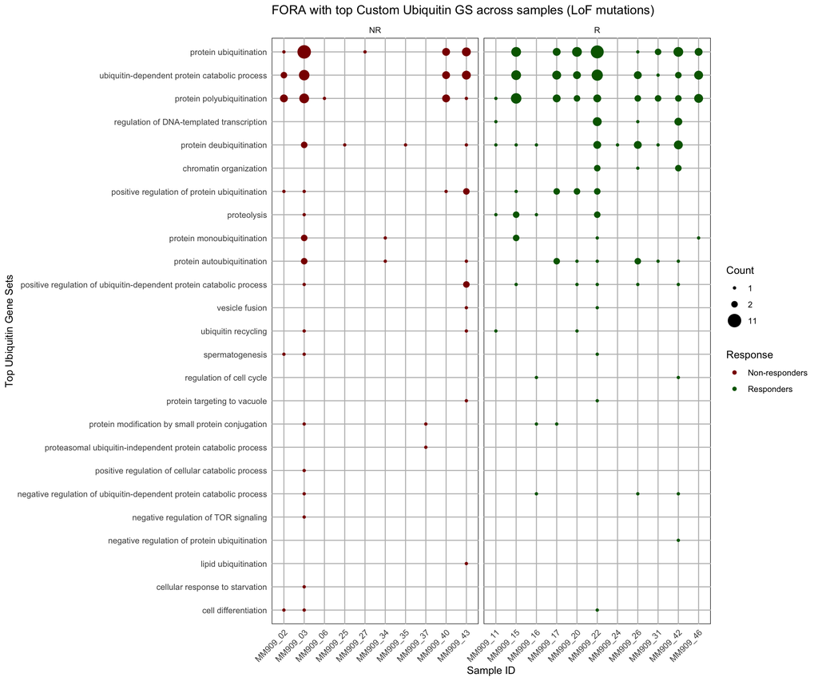

```r
# Define output path
mm909_ubiquitin_lof_plot_path <- file.path(figures_ubgenesets_path,
                              "mm909_ubiquitin_lof_plot.png")

mm909_ubiquitin_lof_plot <- bubble_plot_all(response_df, fora_results_ubiquitin_lof_df, mm909_ubiquitin_lof_plot_path, "FORA with top Custom Ubiquitin GS across samples (LoF mutations)", "Top Ubiquitin Gene Sets")

print(mm909_ubiquitin_lof_plot)
```

### 5.2.2 Visualization: Global heat map

This does not have the filter p.adjust < 0.05.

```r
plot_path <- file.path(figures_ubgenesets_path, "mm909_combinedGS_lof_heat_map.pdf")
combinedGS_lof_plot <- complex_heatmap_genesets(response_df, fora_results_ubiquitin_lof_df, plot_path,
                                    "Heat Map of combined Gene Sets per patient", 16, 12)

# Print
print(combinedGS_lof_plot)
```

[output not shown]

## 5.3 Repeat FORA focusing on categories only

```r
#10 Perform FORA analysis
# Define paths
fora_results_all_csv_path2 <- file.path(results_ubgenesets_path, "fora_results_ubiquitin_cat_all.csv")
fora_results_nonsyn_csv_path2 <- file.path(results_ubgenesets_path, "fora_results_ubiquitin_cat_nonsyn.csv")
fora_results_lof_csv_path2 <- file.path(results_ubgenesets_path, "fora_results_ubiquitin_cat_lof.csv")

# Create gene_sets_df with a list of ensembl_id for each go_parent_id
gene_sets_df <- final_ub_db_df %>%
  dplyr::group_by(category) %>%
  dplyr::summarise(ensembl_id = list(ensembl_id), .groups = 'drop')

# Convert the dataframe to a named list
gene_sets_list <- setNames(gene_sets_df$ensembl_id, gene_sets_df$category)

# Perform FORA analysis for Ubiquitin Gene Sets
# perform_fora_analysis(sample_id_list, list_of_all_ub_mutations, list_of_nonsyn_ub_mutations, list_of_lof_ub_mutations, fora_results_all_csv_path2, fora_results_nonsyn_csv_path2, fora_results_lof_csv_path2, gene_sets_list=gene_sets_list)

# Load fora results
fora_results_ubiquitin_all_df2 <- read.csv(fora_results_all_csv_path2, header = TRUE)[ , -1]
fora_results_ubiquitin_nonsyn_df2 <- read.csv(fora_results_nonsyn_csv_path2, header = TRUE)[ , -1]
fora_results_ubiquitin_lof_df2 <- read.csv(fora_results_lof_csv_path2, header = TRUE)[ , -1]
```

### 5.3.1 Visualization: Top Custom Ubiquitin GS across samples stratified by response (LoF mutations)

This does not have the filter p.adjust < 0.05.

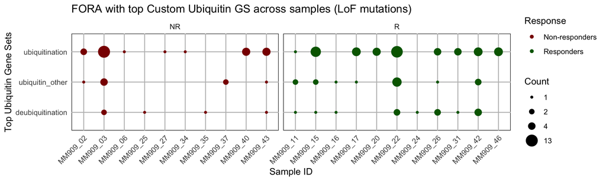

```r
# Define output path
mm909_ubiquitin_lof_plot_path2 <- file.path(figures_ubgenesets_path,
                              "mm909_ubiquitin_cat_lof_plot.png")

mm909_ubiquitin_lof_plot2 <- bubble_plot_all(response_df, fora_results_ubiquitin_lof_df2, mm909_ubiquitin_lof_plot_path2, "FORA with top Custom Ubiquitin GS across samples (LoF mutations)", "Top Ubiquitin Gene Sets")

print(mm909_ubiquitin_lof_plot2)
```

### 5.3.2 Visualization: Global heat map

This does not have the filter p.adjust < 0.05.

```r
plot_path <- file.path(figures_ubgenesets_path, "mm909_combinedGS_cat_lof_heat_map.pdf")
combinedGS_lof_plot <- complex_heatmap_genesets(response_df, fora_results_ubiquitin_lof_df2, plot_path,
                                    "Heat Map of combined Gene Sets per patient", 16, 6)

# Print
print(combinedGS_lof_plot)
```

[output not shown]

## 5.4 FORA using mygene to annotate Ensembl Gene IDs to GO parent terms

```r
#9 Annotate Ensembl Gene IDs to each parent go term to do FORA
# Query the database to find Ensembl IDs for each GO term
go2ensembl_result <- queryMany(ub_parent_terms,
                 scopes='go',
                 fields=c('ensembl.gene', 'name', 'go'),
                 species='human',
                 return.as='DataFrame')
```

```
## Finished
## Pass returnall=TRUE to return lists of duplicate or missing query terms.
```

```r
# Filter result for ensembl
go2ensembl_names <- go2ensembl_result$query
go2ensembl_filtered <- go2ensembl_result$ensembl
names(go2ensembl_filtered) <- go2ensembl_names # Set names

# Convert to data.frame each element of the list
go2ensembl_list <- lapply(go2ensembl_filtered,
                             function(df)
                               if (is.null(df)) data.frame(gene = character())
                               else df %>%
                                as.data.frame())
# Wrangle the data.frame
go2ensembl_list <- lapply(go2ensembl_list,
                             function(x)
                               x %>%
                                dplyr::rename(ensembl_id = gene) %>%
                                dplyr::select(ensembl_id))
# Convert list of df to single data.frame
raw_go2ensembl_df <- bind_rows(go2ensembl_list, .id = "go_parent_id") %>%
  dplyr::distinct()

# Adding go_parent_term
raw_go2ensembl_df <- raw_go2ensembl_df %>%
  dplyr::mutate(go_parent_term = map_chr(go_parent_id, function(id) {
    # Access the term for the given GO ID
    term <- tryCatch({
      eval(parse(text = paste0("all_go_terms$`", id, "`@Term")))
    }, error = function(e) NA)
    return(term)
  }))

#10 Perform FORA analysis
# Define paths
fora_results_all_csv_path_mygene <- file.path(results_ubgenesets_path, "fora_results_ubiquitin_all_mygene.csv")
fora_results_nonsyn_csv_path_mygene <- file.path(results_ubgenesets_path, "fora_results_ubiquitin_nonsyn_mygene.csv")
fora_results_lof_csv_path_mygene <- file.path(results_ubgenesets_path, "fora_results_ubiquitin_lof_mygene.csv")

# Adapt structure to gene_sets_list
gene_sets_df <- raw_go2ensembl_df %>%
  dplyr::group_by(go_parent_term) %>%
  dplyr::summarise(ensembl_ids = list(unique(ensembl_id)), .groups = 'drop')

# Convert the dataframe to a named list
gene_sets_list <- setNames(gene_sets_df$ensembl_ids, gene_sets_df$go_parent_term)

# Perform FORA analysis for Ubiquitin Gene Sets
# perform_fora_analysis(sample_id_list, list_of_all_ub_mutations, list_of_nonsyn_ub_mutations, list_of_lof_ub_mutations, fora_results_all_csv_path_mygene, fora_results_nonsyn_csv_path_mygene, fora_results_lof_csv_path_mygene, gene_sets_list=gene_sets_list)

# Load fora results
fora_results_ubiquitin_all_df_mygene <- read.csv(fora_results_all_csv_path_mygene, header = TRUE)[ , -1]
fora_results_ubiquitin_nonsyn_df_mygene <- read.csv(fora_results_nonsyn_csv_path_mygene, header = TRUE)[ , -1]
fora_results_ubiquitin_lof_df_mygene <- read.csv(fora_results_lof_csv_path_mygene, header = TRUE)[ , -1]
```

### 5.4.1 Visualization: Top Custom Ubiquitin GS across samples stratified by response (LoF mutations)

This does not have the filter p.adjust < 0.05.

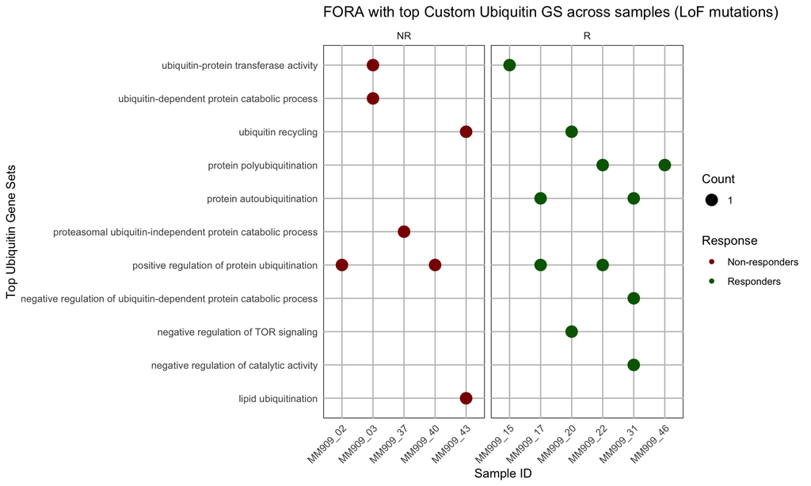

```r
# Define output path
mm909_ubiquitin_lof_plot_path_mygene <- file.path(figures_ubgenesets_path,
                              "mm909_ubiquitin_lof_plot_mygene.png")

mm909_ubiquitin_lof_plot_mygene <- bubble_plot_all(response_df, fora_results_ubiquitin_lof_df_mygene, mm909_ubiquitin_lof_plot_path_mygene, "FORA with top Custom Ubiquitin GS across samples (LoF mutations)", "Top Ubiquitin Gene Sets")

print(mm909_ubiquitin_lof_plot_mygene)
```

### 5.4.2 Visualization: Global heat map

This does not have the filter p.adjust < 0.05.

```r
plot_path_mygene <- file.path(figures_ubgenesets_path, "mm909_combinedGS_lof_heat_map_mygene.pdf")
combinedGS_lof_plot_mygene <- complex_heatmap_genesets(response_df, fora_results_ubiquitin_lof_df_mygene, plot_path_mygene,
                                    "Heat Map of combined Gene Sets per patient", 16, 12)

# Print
print(combinedGS_lof_plot_mygene)
```

[output not shown]

Some notes:

- The plots belong to annotating Ensembl Gene IDs to go_parent_ids with the mygene package, it has nothing to do with ub_db. This is why I get so different results compared to before, I get much less genes annotated.

# 6 Create a binary matrix (LoF - Ubiquitin)

This binary matrix has ubiquitin mutated genes as rows and patients as columns. There is a 1 if a particular gene was mutated at least once for a specific sample, and zero otherwise.

```r
# Create a dataframe for the matrix, initialize with ensembl_id and hugo_symbol, fill 0 for samples
lof_ub_binary <- data.frame(ensembl_id = ub_ensembl_ids, hugo_symbol = rep(NA, length(ub_ensembl_ids)))

# For each sample_id, add a column to lof_ub_binary and initialize with 0
for (sample_id in unique(lof_df_ubiquitin$sample_id)) {
  lof_ub_binary[[sample_id]] <- 0
}

# Map hugo_symbols to the corresponding ensembl_id
hugo_map <- lof_df_ubiquitin[!duplicated(lof_df_ubiquitin$ensembl_id), c("ensembl_id", "hugo_symbol")]
lof_ub_binary$hugo_symbol <- hugo_map$hugo_symbol[match(lof_ub_binary$ensembl_id, hugo_map$ensembl_id)]

# Fill the matrix with 1s where appropriate
for (i in 1:nrow(lof_df_ubiquitin)) {
  row <- lof_df_ubiquitin[i, ]
  if (row$ensembl_id %in% lof_ub_binary$ensembl_id) {
    lof_ub_binary[row$ensembl_id == lof_ub_binary$ensembl_id, row$sample_id] <- 1
  }
}

# Annotate missing Hugo Symbols with Ensembl Gene IDs
missing_hsymbols <- is.na(lof_ub_binary$hugo_symbol)
new_hsymbols <- ENSEMBLtoSYMBOL(lof_ub_binary$ensembl_id[missing_hsymbols])
lof_ub_binary$hugo_symbol[missing_hsymbols] <- new_hsymbols

# Save the lof_binary into a file
lof_ub_binary_out_path <- file.path(results_ubgenesets_path,
                      "lof_ub_binary.csv")
write.csv(lof_ub_binary, file = lof_ub_binary_out_path, row.names = TRUE)

# Display
datatable(lof_ub_binary,
          extensions = c('Buttons',
                         'FixedColumns'),
          options = list(
            dom = 'Bfrtip',
            buttons = c('copy', 'excel', 'csv'),
            scrollX=TRUE,
            pageLength=10,
            fixedColumns = list(leftColumns = 3), # Freeze the first 3 columns
            columnDefs = list(list(
              targets = "_all",
              render = JS(
                "function(data, type, row, meta) {",
                "  return data === null ? 'NA' : data;",
                "}"
              )
            ))
          ),
          caption = "Binary matrix of ubiquitin LoF mutations per sample."
        )
```

|  | ensembl_id | hugo_symbol | MM909_02 | MM909_03 | MM909_06 | MM909_11 | MM909_15 | MM909_16 | MM909_17 | MM909_20 | MM909_22 | MM909_24 | MM909_25 | MM909_26 | MM909_27 | MM909_31 | MM909_34 | MM909_35 | MM909_37 | MM909_40 | MM909_42 | MM909_43 | MM909_46 |
| --- | --- | --- | --- | --- | --- | --- | --- | --- | --- | --- | --- | --- | --- | --- | --- | --- | --- | --- | --- | --- | --- | --- | --- |
| 1 | ENSG00000130985 | UBA1 | 0 | 0 | 0 | 0 | 0 | 0 | 0 | 0 | 0 | 0 | 0 | 0 | 0 | 0 | 0 | 0 | 0 | 0 | 0 | 0 | 0 |
| 2 | ENSG00000126261 | UBA2 | 0 | 1 | 0 | 0 | 0 | 0 | 0 | 0 | 0 | 0 | 0 | 0 | 0 | 0 | 0 | 0 | 0 | 0 | 0 | 0 | 0 |
| 3 | ENSG00000144744 | UBA3 | 0 | 0 | 0 | 0 | 0 | 1 | 0 | 0 | 0 | 0 | 0 | 0 | 0 | 0 | 0 | 0 | 0 | 0 | 0 | 0 | 0 |
| 4 | ENSG00000081307 | UBA5 | 0 | 0 | 0 | 0 | 0 | 0 | 0 | 0 | 0 | 0 | 0 | 0 | 0 | 0 | 0 | 0 | 0 | 0 | 0 | 0 | 0 |
| 5 | ENSG00000033178 | UBA6 | 0 | 0 | 0 | 0 | 0 | 0 | 0 | 0 | 1 | 0 | 0 | 0 | 0 | 0 | 0 | 0 | 0 | 0 | 0 | 0 | 0 |
| 6 | ENSG00000182179 | UBA7 | 0 | 0 | 0 | 0 | 0 | 0 | 0 | 0 | 0 | 0 | 0 | 0 | 0 | 0 | 0 | 0 | 0 | 0 | 0 | 0 | 0 |
| 7 | ENSG00000197548 | ATG7 | 0 | 0 | 0 | 0 | 0 | 0 | 0 | 0 | 0 | 0 | 0 | 0 | 0 | 0 | 0 | 0 | 0 | 0 | 0 | 0 | 0 |
| 8 | ENSG00000159593 | NAE1 | 0 | 0 | 0 | 0 | 0 | 0 | 0 | 0 | 0 | 0 | 0 | 0 | 0 | 0 | 0 | 0 | 0 | 0 | 0 | 0 | 0 |
| 9 | ENSG00000142230 | SAE1 | 0 | 0 | 0 | 0 | 0 | 0 | 0 | 0 | 0 | 0 | 0 | 0 | 0 | 0 | 0 | 0 | 0 | 0 | 0 | 0 | 0 |
| 10 | ENSG00000077721 | UBE2A | 0 | 0 | 0 | 0 | 0 | 0 | 0 | 0 | 0 | 0 | 0 | 0 | 0 | 0 | 0 | 0 | 0 | 0 | 0 | 0 | 0 |

[output cut: 664 more lines]